# Colonization Extinction Summary

## Colonization Models

| Variable | coefficient | Pr(>abs(z)) | AICc | $\Delta$ AICc |
| --- | --- | --- | --- | --- |
| max_sbt_temp_change_abs | 0.239 | 0.000 | 6878.288 | 0.000 |
| max_sst_temp_change_abs_lag1 | -0.240 | 0.001 | 6887.400 | 9.112 |
| min_sbt_temp_change_abs_lag5 | -0.244 | 0.002 | 6888.859 | 10.572 |
| max_sbt_temp_change_abs_lag3 | 0.171 | 0.001 | 6888.938 | 10.650 |
| seas_sbt_temp_change_abs | 0.142 | 0.002 | 6889.498 | 11.211 |
| max_sst_temp_change_abs_lag8 | 0.191 | 0.002 | 6889.901 | 11.614 |
| seas_sst_temp_change_abs_lag8 | 0.127 | 0.004 | 6890.941 | 12.654 |
| seas_sbt_temp_change_abs_lag4 | 0.136 | 0.005 | 6891.397 | 13.109 |
| max_sbt_temp_change_lag8 | -0.115 | 0.006 | 6891.566 | 13.279 |
| seas_sbt_temp_change_abs_lag1 | 0.126 | 0.007 | 6891.960 | 13.672 |

Relative Variable Importance Calculated Akaike Weight for each model, divided by sum of all weights to get a value for relative model importance. Then, summed values for all models including the following variables. This only works when each variable is equally represented.

- Surface (n = 93) importance = 0.02 **versus** Bottom (n = 93) importance = 0.97
- Non lagged (n = 18) importance = 0.96 **versus** Lag (n = 168) importance = 0.03 (despite difference in n)
- Absolute change (n = 60) importance = 0.99 **versus** Raw temp (n = 66) importance = 0.003 **versus** change (n = 60) = 0.005

## Extinction Models

| Variable | coefficient | Pr(>abs(z)) | AICc | $\Delta$ AICc |
| --- | --- | --- | --- | --- |
| seas_sbt_temp_change_abs_lag9 | 0.168 | 0.002 | 6207.213 | 0.000 |
| min_sst_temp_change_lag2 | -0.095 | 0.011 | 6209.860 | 2.647 |
| min_sbt_temp_change_lag7 | -0.116 | 0.011 | 6210.022 | 2.808 |
| seas_sbt_temp_change_abs | 0.116 | 0.013 | 6210.184 | 2.971 |
| max_sbt_temp_change_lag7 | -0.100 | 0.015 | 6210.285 | 3.072 |
| seas_sbt_temp_lag9 | 0.087 | 0.017 | 6210.766 | 3.553 |
| seas_sst_temp_change_lag2 | 0.069 | 0.020 | 6210.908 | 3.695 |
| max_sbt_temp_change_abs_lag9 | 0.177 | 0.028 | 6211.488 | 4.275 |
| max_sst_temp_change_lag1 | -0.098 | 0.038 | 6212.029 | 4.816 |
| max_sbt_temp_change_abs_lag3 | 0.117 | 0.043 | 6212.264 | 5.050 |

Relative Variable Importance

- Surface (n = 93) importance = 0.37 **versus** Bottom (n = 93) importance = 0.63
- Non lagged (n = 18) importance = 0.10 **versus** Lag (n = 168) importance = 0.90 (keep in mind change in n)
- Absolute change (n = 60) importance = 0.47 **versus** Raw temp (n = 66) importance = 0.20 **versus** change (n = 60) = 0.34

Comparisons in lags between colonizations and extinctions

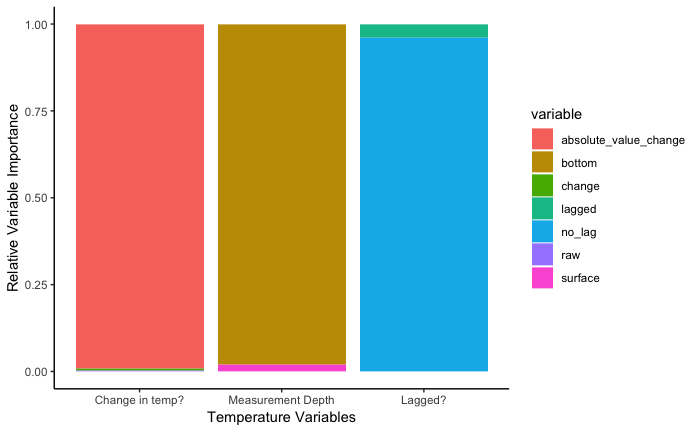

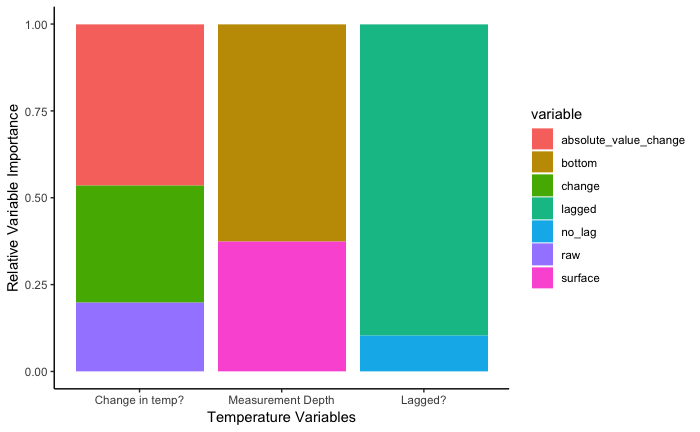

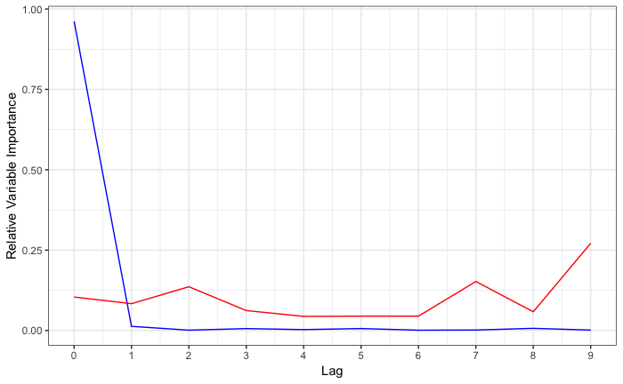

## Traits

### Maximum Age

#### Best Colonization Models

[output not shown]

**Used for models below. Should I instead use top ranking model here?* In top 15, 11/15 shared.

Looked at:

- col ~ temp
- col ~ temp + max.age
- col ~ temp * max.age
- col ~ max.age

Best model includes interaction, (Δ = 1.34 vs w/o interaction)

- variable coefficient Pr(>abs(z)) AICc
- max_sbt_temp_change_abs 0.055470 0.5295 4203.399
- age.max -0.031236 1.15e-07 ***
- max_sbt_temp_change_abs:age.max 0.008543 0.0922 .

As max age increases, impact of temperature on log odds of colonization increases. As max age increases, log odds of colonization decreases.

#### Best Extinction Models

|  | Variable | Coefficient | Pr(>abs(z)) | AICc | Rank for Full Models |
| --- | --- | --- | --- | --- | --- |
| *1 | min_sst_temp_change_lag2 | -0.14436022 | 0.003038827 | 3930.580 | 2 |
| 2 | seas_sbt_temp_change_lag9 | 0.12993554 | 0.005210505 | 3931.628 | not in top 15 |
| 3 | seas_sbt_temp_lag9 | 0.10972665 | 0.013229764 | 3933.519 | 6 |
| 4 | max_sbt_temp_change_abs | 0.15427483 | 0.017742274 | 3933.821 | not in top 15 |
| 5 | min_sst_temp_change_abs_lag6 | 0.16578612 | 0.020123707 | 3934.268 | not in top 15 |
| 6 | min_sbt_temp_change_abs_lag5 | -0.23173199 | 0.036076360 | 3934.596 | not in top 15 |
| 7 | seas_sbt_temp_change_abs | 0.12245319 | 0.032188793 | 3934.761 | 4 |
| 9 | max_sbt_temp_change_lag9 | 0.11439746 | 0.035588475 | 3934.905 | not in top 15 |
| 10 | seas_sst_temp | -0.09460166 | 0.050126076 | 3935.655 | not in top 15 |
| 11 | min_sst_temp_change_abs_lag5 | -0.15868171 | 0.063866384 | 3935.761 | not in top 15 |
| 12 | seas_sst_temp_lag2 | 0.07970154 | 0.044236722 | 3935.820 | 12 |
| 13 | seas_sst_temp_change_abs_lag5 | -0.11465158 | 0.071676787 | 3935.918 | not in top 15 |
| 14 | seas_sst_temp_change_lag2 | 0.06818593 | 0.069610050 | 3936.028 | 7 |
| 15 | seas_sst_temp_change | -0.07118644 | 0.077429810 | 3936.153 | not in top 15 |

Looked at:

- now_ext ~ temp
- now_ext ~ temp + age.max
- now_ext ~ temp * age.max
- now_ext ~ age.max

Best model includes both temp and max age but does not include interaction, but the AICcs are very close (Δ = 0.717 vs w interaction, Δ = 6.656 from other models)

```
                      Estimate Std. Error z value Pr(>abs(z))       AICc
```

- (Intercept) -3.330222 0.228016 -14.605 < 2e-16 *** 3889.425
- min_sst_temp_change_lag2 -0.144548 0.048814 -2.961 0.00306 **
- age.max -0.029182 0.004982 -5.857 4.7e-09 ***

This tells us that as maximum age increases, log odds of going extinct decreases. As change in min temperature experienced between 2-3 years ago increases (positive change, towards warmer), the log odds of extinction decreases.

### Age at Maturity

Hypothesis: as age at maturity increases, odds of going extinct decreases because they likely have a longer generation time, and therefore the population will take longer to respond.

#### Best Colonization Models

|  | Variable | Coefficient | Pr(>abs(z)) | AICc | Rank for Full Models |
| --- | --- | --- | --- | --- | --- |
| 1 | seas_sst_temp_change_abs | 0.16732168 | 0.001055896 | 4237.134 | 12 |
| 2 | max_sst_temp_change_abs_lag1 | -0.26275332 | 0.004143103 | 4238.738 | 2 |
| 3 | max_sbt_temp_change_abs_lag3 | 0.18628409 | 0.003083958 | 4238.804 | 4 |
| 4 | max_sst_temp_change_abs_lag6 | -0.22361557 | 0.014782142 | 4240.889 | not in top 15 |
| *5 | max_sbt_temp_change_abs | 0.15801135 | 0.011635865 | 4241.039 | 1 |
| 6 | max_sst_temp_change_abs_lag8 | 0.19598072 | 0.012668985 | 4241.366 | 6 |
| 7 | max_sbt_temp_change_abs_lag1 | 0.15825795 | 0.014922452 | 4241.440 | 11 |
| 9 | seas_sbt_temp_change_abs | 0.13079589 | 0.017830284 | 4241.690 | 5 |
| 10 | seas_sbt_temp_change_abs_lag4 | 0.13424702 | 0.024563505 | 4242.176 | 8 |
| 11 | seas_sst_temp_change_abs_lag6 | -0.13386926 | 0.033532762 | 4242.414 | not in top 15 |
| 12 | seas_sbt_temp_change_abs_lag1 | 0.12498712 | 0.031649631 | 4242.646 | 10 |
| 13 | min_sbt_temp_change_abs_lag5 | -0.19180573 | 0.054000799 | 4243.150 | 3 |
| 14 | seas_sst_temp_change_lag5 | -0.07497315 | 0.049187743 | 4243.216 | not in top 15 |
| 15 | seas_sbt_temp_lag10 | 0.07724898 | 0.059318089 | 4243.639 | not in top 15 |

**Used for models below* In top 15, 11/15 shared.

Looked at:

- col ~ temp
- col ~ temp + age.maturity
- col ~ temp * age.maturity
- col ~ age.maturity

Best model includes temperature and age at maturity, but not an interaction ($/Delta$ = 1.94 vs w/ interaction):

- max_sbt_temp_change_abs 0.15503 0.0132 4236.753
- age.maturity -0.03818 0.0171

#### Extinction Model

|  | Variable | Coefficient | Pr(>abs(z)) | AICc | Rank for Full Models | Coefficient for Full Models |
| --- | --- | --- | --- | --- | --- | --- |
| 1 | min_sst_temp_change_lag2 | -0.14805497 | 0.002710857 | 3920.109 | 2 | -0.09 |
| 2 | seas_sbt_temp_change_lag9 | 0.12861632 | 0.006329875 | 3921.697 | not in top 15 |  |
| 3 | seas_sbt_temp_lag9 | 0.11207541 | 0.011862688 | 3923.042 | 6 | 0.09 |
| 4 | max_sbt_temp_change_abs | 0.15619946 | 0.016642456 | 3923.456 | not in top 15 |  |
| 5 | min_sst_temp_change_abs_lag6 | 0.16612378 | 0.020897770 | 3924.076 | not in top 15 |  |
| 6 | min_sbt_temp_change_abs_lag5 | -0.23921218 | 0.032703088 | 3924.162 | not in top 15 |  |
| 7 | seas_sbt_temp_change_abs | 0.12215822 | 0.032750203 | 3924.536 | 4 | 0.12 |
| 9 | seas_sst_temp_lag2 | 0.08894160 | 0.021276070 | 3924.730 | 12 | 0.06 |
| 10 | seas_sst_temp_change | -0.07914067 | 0.053147439 | 3925.275 | not in top 15 |  |
| 11 | max_sbt_temp_change_lag9 | 0.10522327 | 0.055746506 | 3925.392 | not in top 15 |  |
| 12 | min_sst_temp_change_abs_lag5 | -0.16304438 | 0.059969373 | 3925.406 | not in top 15 |  |
| 13 | seas_sst_temp_change_lag2 | 0.07202288 | 0.059464663 | 3925.501 | 7 | 0.07 |
| 14 | seas_sst_temp | -0.09394699 | 0.055661858 | 3925.636 | not in top 15 |  |
| 15 | min_sst_temp_change | 0.09385684 | 0.072201812 | 3925.738 | not in top 15 |  |

Of top 15, only 5 are shared

Best model includes both age at maturity and temp but not the interaction ($\Delta$ = 1.926 vs w/ interaction).

```
                     Estimate Std. Error z value Pr(>abs(z))    AICc
```

- (Intercept) -3.54614 0.23907 -14.833 < 2e-16 *** 3906.268
- min_sst_temp_change_lag2 -0.14810 0.04939 -2.998 0.002714 **
- age.maturity -0.06855 0.01846 -3.714 0.000204 ***

This tells us that as age at maturity increases,log odds of extinction decrease. Also, as change in minimum temperature experienced between 2-3 years ago increases (towards positive), log odds of extinction decreases.

### Trophic Level

#### Best Colonization Models

|  | Variable | Coefficient | Pr(>abs(z)) | AICc | Rank for Full Models |
| --- | --- | --- | --- | --- | --- |
| 1 | seas_sst_temp_change_abs | 0.17121179 | 0.0005599279 | 4525.486 | 12 |
| 2 | max_sbt_temp_change_abs_lag3 | 0.19678089 | 0.0013246068 | 4526.919 | 4 |
| *3 | max_sbt_temp_change_abs | 0.18509626 | 0.0021952362 | 4527.742 | 1 |
| 4 | max_sst_temp_change_abs_lag1 | -0.25709293 | 0.0033255361 | 4527.955 | 2 |
| 5 | seas_sbt_temp_change_abs | 0.15728890 | 0.0034775899 | 4528.408 | 5 |
| 6 | max_sbt_temp_change_abs_lag1 | 0.16544380 | 0.0096094080 | 4530.271 | 11 |
| 7 | seas_sbt_temp_change_abs_lag1 | 0.13431316 | 0.0183946976 | 4531.309 | 10 |
| 8 | seas_sbt_temp_change_abs_lag4 | 0.13162107 | 0.0232351577 | 4531.668 | 8 |
| 9 | min_sbt_temp_change_abs | 0.17182671 | 0.0196874934 | 4531.795 | not in top 15 |
| 10 | max_sst_temp_change_abs_lag8 | 0.16963749 | 0.0255186622 | 4532.091 | 6 |
| 11 | min_sbt_temp_change_abs_lag5 | -0.20316841 | 0.0397350249 | 4532.176 | 3 |
| 12 | max_sst_temp_change_abs_lag6 | -0.18049426 | 0.0381593586 | 4532.251 | not in top 15 |
| 13 | seas_sst_temp_change_lag5 | -0.07645147 | 0.0360758538 | 4532.280 | not in top 15 |
| 14 | max_sst_temp_change_abs | 0.20292370 | 0.0327597085 | 4532.339 | 14 |
| 15 | min_sst_temp_change_abs | 0.13663573 | 0.0333662358 | 4532.452 | not in top 15 |

**Used for models below* Of top 15 models, 11/15 shared.

Looked at:

- col ~ temp
- col ~ temp + trophic level
- col ~ temp * trophic level
- col ~ trophic level

Best model includes temperature and trophic level, including interaction ((Δ = 6.027 vs w/o interaction): * variable coefficient Pr(>abs(z)) AICc  
* max_sbt_temp_change_abs 0.93859 0.000332 4509.615 * tl -0.14904 0.226275  
* max_sbt_temp_change_abs:tl -0.20651 0.003700

#### Best Extinction Models

|  | Variable | Coefficient | Pr(>abs(z)) | AICc | Rank for Full Models | Coefficient for Full Models |
| --- | --- | --- | --- | --- | --- | --- |
| *1 | min_sst_temp_change_lag2 | -0.12605189 | 0.008882239 | 4205.455 | 2 | -0.09 |
| 2 | seas_sbt_temp_change_abs | 0.13647286 | 0.014522389 | 4206.321 | 4 | 0.12 |
| 3 | seas_sbt_temp_change_lag9 | 0.11068561 | 0.016010438 | 4206.530 | not in top 15 |  |
| 4 | seas_sbt_temp_lag9 | 0.10832214 | 0.014587647 | 4206.647 | 6 | 0.09 |
| 5 | min_sst_temp_change_abs_lag6 | 0.17395683 | 0.014698403 | 4206.661 | not in top 15 |  |
| 6 | min_sbt_temp_change_abs_lag5 | -0.25022141 | 0.023335227 | 4206.734 | not in top 15 |  |
| 7 | max_sbt_temp_change_abs | 0.15091446 | 0.018910307 | 4206.845 | not in top 15 |  |
| 8 | min_sst_temp_change_abs_lag7 | 0.16683645 | 0.017394540 | 4206.863 | 15 | 0.11 |
| 9 | min_sst_temp_change_abs_lag5 | -0.18898669 | 0.027881516 | 4207.251 | not in top 15 |  |
| 10 | min_sbt_temp_change_lag7 | -0.10660642 | 0.056611513 | 4208.757 | 3 | -0.12 |
| 11 | seas_sst_temp_lag2 | 0.07887305 | 0.050759977 | 4208.927 | 12 | 0.07 |
| 12 | seas_sst_temp_change_abs_lag5 | -0.11074422 | 0.077570136 | 4208.999 | not in top 15 |  |
| 13 | min_sst_temp_change | 0.08871614 | 0.078886342 | 4209.073 | not in top 15 |  |
| 14 | seas_sst_temp | -0.08790929 | 0.067876817 | 4209.092 | not in top 15 |  |
| 15 | max_sbt_temp_change_lag9 | 0.09267424 | 0.081161794 | 4209.182 | not in top 15 |  |

**Used for models below*

Of top 15, only 6 are shared.

Looked at:

- now_Ext ~ temp
- now_Ext ~ temp + trophic level
- now_Ext ~ temp * trophic level
- now_Ext ~ trophic level

Best model includes both trophic level and temperature, but not an interaction ( $\Delta$ = 1.914 vs. w/ interaction).

```
                     Estimate Std. Error z value Pr(>abs(z))      AICc
```

- (Intercept) -2.36179 0.44387 -5.321 1.03e-07 *** 4192.295
- min_sst_temp_change_lag2 -0.12635 0.04823 -2.620 0.0088 **
- tl -0.39633 0.10089 -3.928 8.55e-05 ***

This tells us that as trophic level increases, log odds of extinction decreases. As change in minimum temperature experienced between 2-3 years ago towards positive increases, the log odds of extinction decreases.